# 時系列分析 第 9 回

単位根過程

Kenichiro Tamaki

2022 年 6 月 6 日

# 5 単位根過程

## 5.1 単位根過程の性質

### 5.1.1 単位根過程

定常過程では, 平均と自己共分散が一定である.

- トレンドをもたない
- 平均回帰的

経済・ファイナンス分野では定常性を満たさないデータが多い.

- GDP, 物価 (トレンドがある)
- 株価, 為替レート (平均回帰的でない)

**非定常過程の例**

> **定義5.1 (単位根過程, p.105)**  
> 原系列 $y_{t}$ は非定常過程であり, 差分系列 $\Delta y_{y} = y_{t} - y_{t - 1}$ は定常過程であるとき, 過程は単位根過程 (unit root process) という.

AR 特性方程式が $z = 1$ を解にもつので, 単位根過程という.

> **定義5.2 (和分過程, p.106)**  
> $d - 1$ 階差分系列は非定常過程であり, $d$ 階差分系列は定常過程であるとき, $d$ 次和分過程 (integrated process), または $I(d)$ 過程という.

単位根過程 $y_{t} \sim I(1)$, 定常過程 $y_{t} \sim I(0)$ と表す.

> **定義5.3 (ARIMA 過程, p.106)**  
> $d$ 階差分系列は定常かつ反転可能な ARMA$(p, q)$ 過程であるとき, ARIMA$(p, d, q)$ 過程という

$d - 1$ 階差分系列は非定常過程である.

**代表的な単位根過程**

> **定義5.4 (ランダム・ウォーク, p.106)**
> $$\begin{align*}
> & y_{t} = \delta + y_{t - 1} + \varepsilon_{t}, \quad
> \varepsilon_{t} \sim \text{iid } (0, \sigma^{2}) \\
> & y_{0} = 0
> \end{align*}$$
> のとき, $y_{t}$ をドリフト率 $\delta$ のランダム・ウォーク (random walk) という.

AR 係数が $1$ の非定常な AR(1) 過程である. $\Delta y_{t} = \delta + \varepsilon_{t}$ は定常過程であり, 特性方程式は $\Phi(z) = 1 - z = 0$ であるから, $z = 1$ を解にもつ.

### 5.1.2 単位根過程のトレンド

ランダム・ウォークを考える.
$$\begin{align*}
y_{t} &= \delta + y_{t - 1} + \varepsilon_{t} \\
&= 2 \delta + y_{t - 2} + \varepsilon_{t - 1} + \varepsilon_{t} \\
& \quad \vdots \\
&= \delta t + y_{0} + \varepsilon_{1} + \dots + \varepsilon_{t} \\
&= \delta t + \nu_{t} \quad (\nu_{t} = \varepsilon_{1} + \dots +
\varepsilon_{t})
\end{align*}$$

- 線形トレンド $\delta t$
  - ドリフト率 $\delta$ は線形トレンドの傾き
  - 時間の関数で確定的トレンド
- 確定的トレンドを除去した系列 $y_{t} - \delta t = \nu_{t}$
  - $V(\nu_{t}) = \sigma^{2} t$ であるから, 分散が増大する
  - $\nu_{t}$ を確率的トレンドという

> **定義5.5 (トレンド定常過程, p.107)**
> $x_{t}$ が定常過程のとき
> $$y_{t} = c + \delta t + x_{t}$$
> をトレンド定常過程 (trend stationary process) という.
- トレンド定常過程は非定常であるが, (確定的) トレンドを取り除けば定常
- 単位根過程は非定常であり, (確定的) トレンドの取り除いても非定常

**模擬データ**

**単位根過程の生成**

```r
set.seed(10) # 乱数を指定
T <- 200 # 標本数
# ドリフト率 0 のランダム・ウォーク
x1 <- arima.sim(list(order = c(0, 1, 0)), n = T)
# 累積和, ドリフト率0.1のランダム・ウォーク
x2 <- cumsum(rnorm(T) + 0.1)
```

**トレンド定常過程の生成**

```r
set.seed(11) # 乱数を指定
# 正規分布
y1 <- 0.1 * (1:T) + rnorm(T, sd = 4)
# AR(1)
y2 <- 0.1 * (1:T) + arima.sim(list(order = c(1, 0, 0), ar = 0.8), n = T)
```

**時系列とコレログラムのプロット**

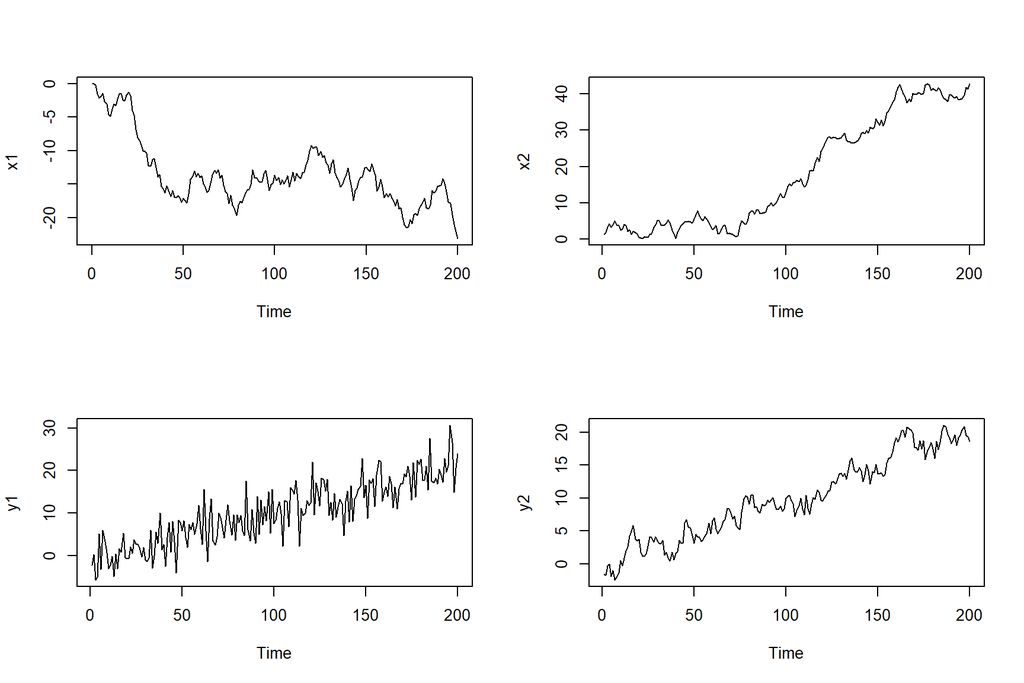

```r
par(mfrow = c(2, 2)) # プロット画面を 2 行 2 列に分割
plot(x1); ts.plot(x2) # 単位根過程の時系列プロット
ts.plot(y1); plot(y2) # トレンド定常過程の時系列プロット
```

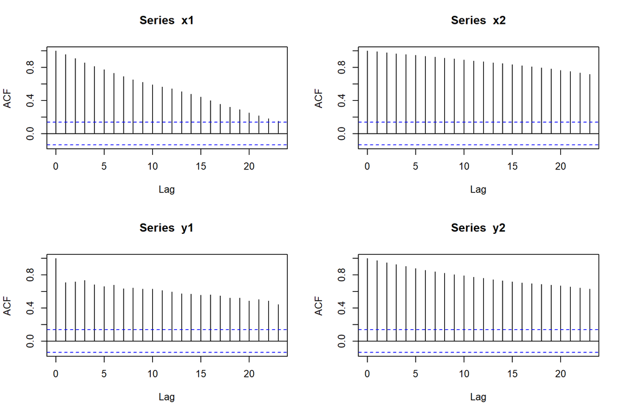

```r
acf(x1); acf(x2) # 単位根過程のコレログラム
acf(y1); acf(y2) # トレンド定常過程のコレログラム
```

$x$ は単位根過程, $y$ はトレンド定常過程である. 時系列プロットやコレログラムからは違いが分からないが, 性質の異なるデータである.

### 5.1.3 単位根過程の予測

ドリフト率 $\delta = 0$ とすると
$$y_{t + h} = y_{t} + \varepsilon_{t + h} + \dots + \varepsilon_{t + 1}.$$

これより, $h$ 期先最適予測は $\hat{y}_{t + h \vert t} = y_{t}$ であるから
$$\text{MSE} \left( \hat{y}_{t + h \vert t} \right) = E[ (\varepsilon_{t +
h} + \dots + \varepsilon_{t + 1})^{2} ] = \sigma^{2} h.$$

よって, $h \to \infty$ のとき MSE は発散するので, 単位根過程の長期的な予測は困難である.

### 5.1.4 単位根過程のインパルス応答関数

$y_{t + h} = y_{t} + \varepsilon_{t + h} + \dots + \varepsilon_{t + 1}$ であるから
$$\text{IRF} (k) = \frac{\partial y_{t + h}}{\partial \varepsilon_{t}} =
1.$$

これより, ショックは恒久的な影響をもつ. 定常過程に対しては, ショックは一時的な影響しかもたない.

- 単位根過程とトレンド定常過程では, 導かれる結論が大きく異なる
- 単位根過程かどうかを判断する (検定する) ことが重要となる

## 5.2 単位根検定

### 5.2.1 DF (Dickey-Fuller) 検定

真の過程を AR$(1)$ とし, AR 係数が $1$ かどうかを検定する.
$$H_{0}: \rho = 1, \quad H_{1}: \lvert \rho \rvert < 1$$

次の3つの場合を考える必要がある.
$$\begin{align*}
& 1. \quad H_{0}: y_{t} = y_{t - 1} + u_{t}, & & H_{1}:
y_{t} = \rho y_{t - 1} + u_{t}, \quad \rho < 1 \\
& 2. \quad H_{0}: y_{t} = y_{t - 1} + u_{t}, & & H_{1}:
y_{t} = c + \rho y_{t - 1} + u_{t}, \quad \rho < 1 \\
& 3. \quad H_{0}: y_{t} = c + y_{t - 1} + u_{t}, & & H_{1}:
y_{t} = c + \delta t + \rho y_{t - 1} + u_{t}, \quad \rho < 1
\end{align*}$$

1. データがトレンドをもたず, 期待値が $0$ である場合
2. データがトレンドをもたず, 期待値が $0$ でない場合
3. データがトレンドをもつ場合

### 5.2.2 ADF (augmented DF, 拡張 DF) 検定

DF 検定では, 真のモデルを AR(1) であるが, 真のモデルを AR$(p)$ に拡張した DF 検定が ADF 検定である.

- 次数 $p$ は情報量基準 (AIC, BIC など) を用いて決定する

次の AR$(p)$ を考える.
$$y_{t} = c + \phi_{1} y_{t - 1} + \dots + \phi_{p} y_{t - p} +
\varepsilon_{t}$$

$y_{t}$ が単位根過程であるとき, AR 特性方程式は $z = 1$ を解にもつので $\phi_{1} + \dots + \phi_{p} = 1$ を検定する.

$$\begin{cases}
\rho = \phi_{1} + \dots + \phi_{p} \\
\zeta_{k} = -(\phi_{k + 1} + \dots + \phi_{p}), \quad k = 1, \dots, p -
1
\end{cases}$$
とおくと
$$\Delta y_{t} = c + (\rho - 1) y_{t - 1} + \zeta_{1} \Delta y_{t - 1}
\dots + \zeta_{p - 1} \Delta y_{t - p + 1} + \varepsilon_{t}.$$

上記を用いて $\rho = 1$ の検定を行えば良いが, DF 検定と同様に3つの場合を考える必要がある.

**データがトレンドをもつ場合 (Type 3, trend)**

推定に用いるモデルは次である.
$$\Delta y_{t} = c + \delta t + (\rho - 1) y_{t - 1} + \zeta_{1} \Delta
y_{t - 1} \dots + \zeta_{p - 1} \Delta y_{t - p + 1} + \varepsilon_{t}$$

次の3つの帰無仮説を考える.
$$\begin{align}
& 3.1 \quad H_{0}: \rho = 1 & & \ (\text{tau3}, \ \delta =
0, & & N(0,1), \ \delta \neq 0) \\
& 3.2 \quad H_{0}: \rho = 1, \quad c = 0, \quad \delta = 0&
& \ (\text{phi2}) \\
& 3.3 \quad H_{0}: \rho = 1, \quad \delta = 0 & & \
(\text{phi3})
\end{align}$$

**データがトレンドをもたず, 期待値が $0$ でない場合 (Type 2, drift)**

推定に用いるモデルは次である.
$$\Delta y_{t} = c + (\rho - 1) y_{t - 1} + \zeta_{1} \Delta y_{t - 1}
\dots + \zeta_{p - 1} \Delta y_{t - p + 1} + \varepsilon_{t}$$

**データがトレンドをもたず, 期待値が $0$ である場合 (Type 1, none)**

推定に用いるモデルは次である.
$$\Delta y_{t} = (\rho - 1) y_{t - 1} + \zeta_{1} \Delta y_{t - 1} \dots +
\zeta_{p - 1} \Delta y_{t - p + 1} + \varepsilon_{t}$$

次の帰無仮説を考える.
$$\begin{align}
1.1 \quad H_{0}: \rho = 1 & & \ (\text{tau1})
\end{align}$$

### 5.2.3 PP (Phillips-Perron) 検定

PP 検定 は, DF 検定の撹乱項を拡張した検定である. 撹乱項に自己相関や分散不均一性 (heteroskedasticity) を仮定する.

## R での単位根検定

### 手順

1. プロットや仮説検定を用いて, トレンドの有無, 期待値が $0$ かどうかを調べ, 適切な仮説を設定する  
   判断が困難な場合は, 最も制約が少ない仮説を用いる
2. 適切な仮説の下で, 検定統計量の値を求める
3. 検定統計量の値と棄却域を比較し, 検定を判断する
   - 帰無仮説 (単位根過程である) を棄却できない ⇒ 定常過程であると判断できない  
     差分系列に単位根検定を行う  
     定常過程になるまで繰り返す (過剰差分に注意)
   - 帰無仮説 (単位根過程である) を棄却できる ⇒ 定常過程であると判断できる

単位根過程の漸近理論は定常過程の場合と大きく異なるので, $p$ 値を厳密に求めることは困難である.

### ADF検定

パッケージ urca を用いて ADF 検定を行う.

```r
library(urca) # パッケージの読込
```

一般的に, トレンドの有無や, 期待値が $0$ かどうかの判断は困難であるから, まずは Type 3 で検定を行い, 帰無仮説を棄却できない場合は, さらに Type 2 → Type 1 の順に検定を行う.

まず, 独立な模擬データに対して単位根検定を行う.

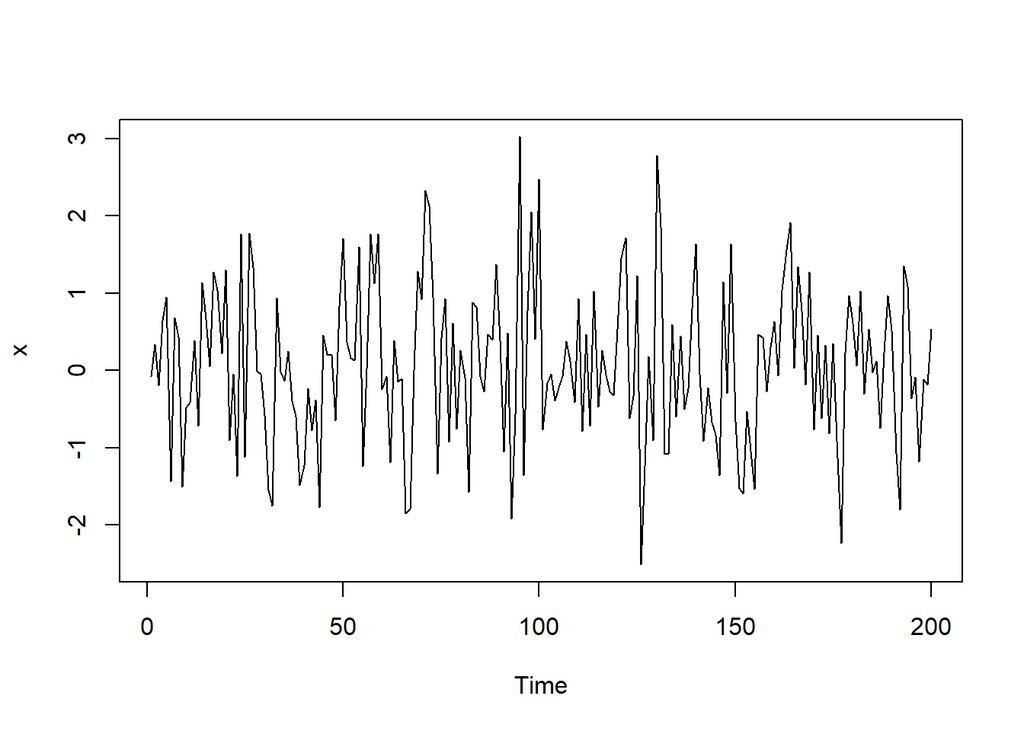

```r
T <- 200 # 標本数
x <- rnorm(T) # 標準正規分布
ts.plot(x) # 時系列プロット
```

Type 3 の検定を行う.

```r
# ADF検定
ur.x <- ur.df(x, # 標本
              type = "trend", # Type 3
              lags = 10, # AR の最大次数
              selectlags = "BIC") # BIC を用いて AR 次数を決定
ur.x # 検定統計量の値
```

```
##
## ###############################################################
## # Augmented Dickey-Fuller Test Unit Root / Cointegration Test #
## ###############################################################
##
## The value of the test statistic is: -8.9381 26.6328 39.9463
```

帰無仮説 3.1, 3.2, 3.3 に対する検定統計量の値が, それぞれ $-8.938, 26.63, 39.95$ である.

```r
ur.x@cval # 棄却域
```

```
##       1pct  5pct 10pct
## tau3 -3.99 -3.43 -3.13
## phi2  6.22  4.75  4.07
## phi3  8.43  6.49  5.47
```

tau3 は, 帰無仮説 3.1 に対する棄却域 (検定統計量の値がこれより小さいと棄却) である. phi2, phi3 は, それぞれ帰無仮説 3.2, 3.3 に対する棄却域 (検定統計量の値がこれより大きいと棄却) である.

tau3 の値 $-8.938$ は $-3.99$ より小さいので, 有意水準 $1 \%$ で帰無仮説を棄却できる. つまり, x は定常過程であると判断できる.

次に, 5.1.2 で作成した模擬データに対して ADF 検定を行う.

**単位根過程 (ドリフト率 $0$ のランダム・ウォーク)**

```r
# ADF検定
ur.x1 <- ur.df(x1, # 標本
               type = "trend", # Type 3
               lags = 10, # AR の最大次数
               selectlags = "BIC") # BIC を用いて AR 次数を決定
ur.x1 # 検定統計量の値
```

```
##
## ###############################################################
## # Augmented Dickey-Fuller Test Unit Root / Cointegration Test #
## ###############################################################
##
## The value of the test statistic is: -2.089 2.0006 2.182
```

```r
ur.x1@cval # 棄却域
```

```
##       1pct  5pct 10pct
## tau3 -3.99 -3.43 -3.13
## phi2  6.22  4.75  4.07
## phi3  8.43  6.49  5.47
```

tau3 の値 $-2.089$ は $-3.13$ より大きいので, 有意水準 $10 \%$ で帰無仮説を棄却できない. 全ての帰無仮説が棄却できない場合は, Type 2 の検定を行う.

```r
# ADF検定
ur.x1 <- ur.df(x1, # 標本
               type = "drift", # Type 2
               lags = 10, # AR の最大次数
               selectlags = "BIC") # BIC を用いて AR 次数を決定
ur.x1 # 検定統計量の値
```

```
##
## ###############################################################
## # Augmented Dickey-Fuller Test Unit Root / Cointegration Test #
## ###############################################################
##
## The value of the test statistic is: -1.7146 2.2869
```

帰無仮説 2.1, 2.2 に対する検定統計量の値が, それぞれ $-1.715, 2.287$ である.

```r
ur.x1@cval # 棄却域
```

```
##       1pct  5pct 10pct
## tau2 -3.46 -2.88 -2.57
## phi1  6.52  4.63  3.81
```

tau2 は, 帰無仮説 2.1 に対する棄却域 (検定統計量の値がこれより小さいと棄却) である. phi1 は, 帰無仮説 2.2 に対する棄却域 (検定統計量の値がこれより大きいと棄却) である.

```r
# ADF検定
ur.x1 <- ur.df(x1, # 標本
               type = "none", # Type 1
               lags = 10, # AR の最大次数
               selectlags = "BIC") # BIC を用いて AR 次数を決定
ur.x1 # 検定統計量の値
```

```
##
## ###############################################################
## # Augmented Dickey-Fuller Test Unit Root / Cointegration Test #
## ###############################################################
##
## The value of the test statistic is: 0.7267
```

帰無仮説 1.1 に対する検定統計量の値が, $0.7267$ である.

```r
ur.x1@cval # 棄却域
```

```
##       1pct  5pct 10pct
## tau1 -2.58 -1.95 -1.62
```

tau1 は, 帰無仮説 1.1 に対する棄却域 (検定統計量の値がこれより小さいと棄却) である.

tau1 の値 $0.7267$ は $-1.62$ より大きいので, 有意水準 $10 \%$ で帰無仮説を棄却できない. Type 1 ～ 3 における全ての帰無仮説を棄却できないので, 帰無仮説を受容し単位根過程であると判断する.

x1 の差分系列を考える.

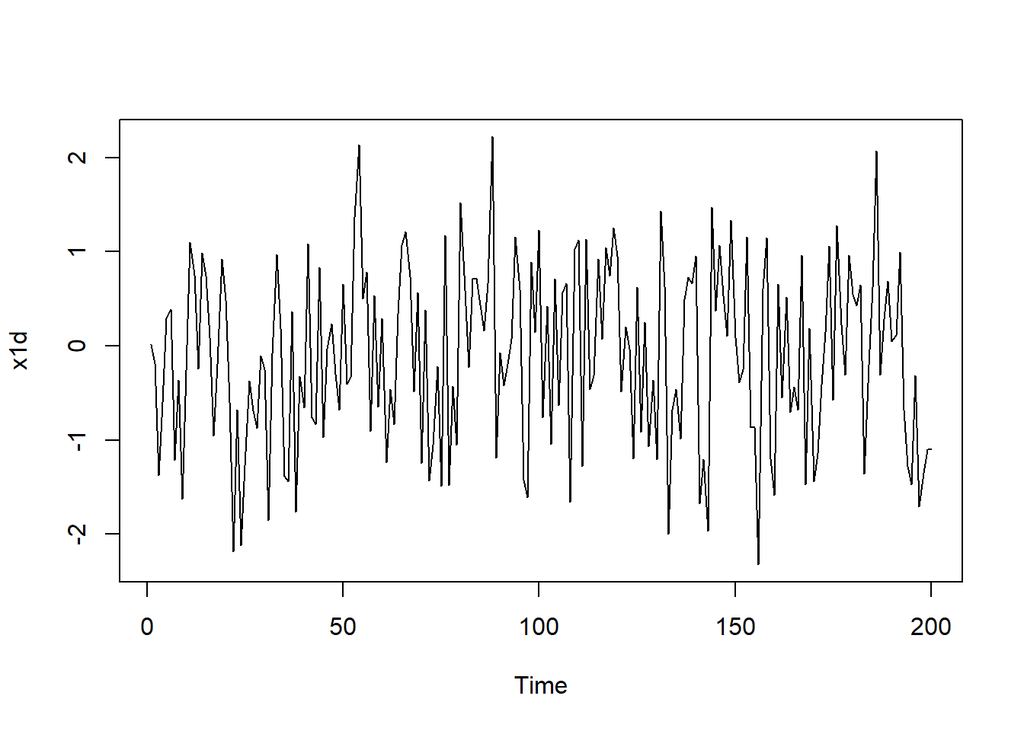

```r
x1d <- diff(x1) # 差分系列
ts.plot(x1d) # 時系列プロット
```

```r
# ADF検定
ur.x1d <- ur.df(x1d, # 標本
               type = "trend", # Type 3
               lags = 10, # AR の最大次数
               selectlags = "BIC") # BIC を用いて AR 次数を決定
ur.x1d # 検定統計量の値
```

```
##
## ###############################################################
## # Augmented Dickey-Fuller Test Unit Root / Cointegration Test #
## ###############################################################
##
## The value of the test statistic is: -8.3883 23.4686 35.1831
```

```r
ur.x1d@cval # 棄却域
```

```
##       1pct  5pct 10pct
## tau3 -3.99 -3.43 -3.13
## phi2  6.22  4.75  4.07
## phi3  8.43  6.49  5.47
```

tau3 の値 $-8.388$ は $-3.99$ より小さいので, 有意水準 $1 \%$ で帰無仮説を棄却できる. つまり, x1 の差分系列 は定常過程であると判断できる.

**x2: 単位根過程 (ドリフト率 $0.1$ のランダム・ウォーク)**

```r
# ADF検定
ur.x2 <- ur.df(x2, # 標本
               type = "trend", # Type 3
               lags = 10, # AR の最大次数
               selectlags = "BIC") # BIC を用いて AR 次数を決定
ur.x2 # 検定統計量の値
```

```
##
## ###############################################################
## # Augmented Dickey-Fuller Test Unit Root / Cointegration Test #
## ###############################################################
##
## The value of the test statistic is: -2.3763 4.256 3.2199
```

```r
ur.x2@cval # 棄却域
```

```
##       1pct  5pct 10pct
## tau3 -3.99 -3.43 -3.13
## phi2  6.22  4.75  4.07
## phi3  8.43  6.49  5.47
```

有意水準 $5 \%$ で全ての帰無仮説を棄却できないので, Type 2 の検定を行う.

```r
# ADF検定
ur.x2 <- ur.df(x2, # 標本
               type = "drift", # Type 2
               lags = 10, # AR の最大次数
               selectlags = "BIC") # BIC を用いて AR 次数を決定
ur.x2 # 検定統計量の値
```

```
##
## ###############################################################
## # Augmented Dickey-Fuller Test Unit Root / Cointegration Test #
## ###############################################################
##
## The value of the test statistic is: 0.1565 3.0868
```

```r
ur.x2@cval # 棄却域
```

```
##       1pct  5pct 10pct
## tau2 -3.46 -2.88 -2.57
## phi1  6.52  4.63  3.81
```

有意水準 $1 \%$ で全ての帰無仮説を棄却できないので, Type 1 の検定を行う.

```r
# ADF検定
ur.x2 <- ur.df(x2, # 標本
               type = "none", # Type 1
               lags = 10, # AR の最大次数
               selectlags = "BIC") # BIC を用いて AR 次数を決定
ur.x2 # 検定統計量の値
```

```
##
## ###############################################################
## # Augmented Dickey-Fuller Test Unit Root / Cointegration Test #
## ###############################################################
##
## The value of the test statistic is: 2.0031
```

```r
ur.x2@cval # 棄却域
```

```
##       1pct  5pct 10pct
## tau1 -2.58 -1.95 -1.62
```

有意水準 $1 \%$で帰無仮説を棄却できない. Type 1 ～ 3 における全ての帰無仮説が棄却できないので, 帰無仮説を受容し単位根過程であると判断する.

x2 の差分系列を考える.

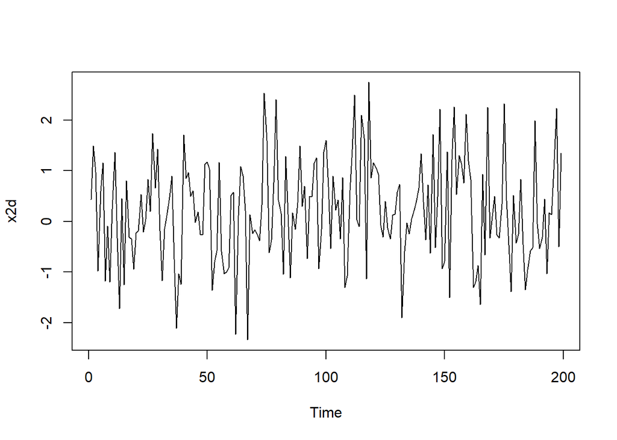

```r
x2d <- diff(x2) # 差分系列
ts.plot(x2d) # 時系列プロット
```

```r
# ADF検定
ur.x2d <- ur.df(x2d, # 標本
               type = "trend", # Type 3
               lags = 10, # AR の最大次数
               selectlags = "BIC") # BIC を用いて AR 次数を決定
ur.x2d # 検定統計量の値
```

```
##
## ###############################################################
## # Augmented Dickey-Fuller Test Unit Root / Cointegration Test #
## ###############################################################
##
## The value of the test statistic is: -9.3493 29.1578 43.7364
```

```r
ur.x2d@cval # 棄却域
```

```
##       1pct  5pct 10pct
## tau3 -3.99 -3.43 -3.13
## phi2  6.22  4.75  4.07
## phi3  8.43  6.49  5.47
```

**y1: トレンド定常過程 (トレンド + 正規分布)**

```r
# ADF検定
ur.y1 <- ur.df(y1, # 標本
               type = "trend", # Type 3
               lags = 10, # AR の最大次数
               selectlags = "BIC") # BIC を用いて AR 次数を決定
ur.y1 # 検定統計量の値
```

```
##
## ###############################################################
## # Augmented Dickey-Fuller Test Unit Root / Cointegration Test #
## ###############################################################
##
## The value of the test statistic is: -10.478 36.7818 54.8956
```

```r
ur.y1@cval # 棄却域
```

```
##       1pct  5pct 10pct
## tau3 -3.99 -3.43 -3.13
## phi2  6.22  4.75  4.07
## phi3  8.43  6.49  5.47
```

tau3 の値 $-10.48$ は $-3.99$ より小さいので, 有意水準 $1 \%$ で帰無仮説を棄却できる. つまり, y1 はトレンド定常過程であると判断できる.

**y2:トレンド定常過程 (トレンド + AR(1))**

```r
# ADF検定
ur.y2 <- ur.df(y2, # 標本
               type = "trend", # Type 3
               lags = 10, # AR の最大次数
               selectlags = "BIC") # BIC を用いて AR 次数を決定
ur.y2 # 検定統計量の値
```

```
##
## ###############################################################
## # Augmented Dickey-Fuller Test Unit Root / Cointegration Test #
## ###############################################################
##
## The value of the test statistic is: -4.5328 7.6103 10.3294
```

```r
ur.y2@cval # 棄却域
```

```
##       1pct  5pct 10pct
## tau3 -3.99 -3.43 -3.13
## phi2  6.22  4.75  4.07
## phi3  8.43  6.49  5.47
```

tsu3 の値 $-4.533$ は $-3.99$ より小さいので, 有意水準 $1 \%$ で帰無仮説を棄却できる. つまり, y2 はトレンド定常過程であると判断できる.

**仮説の設定が適切でない場合**

参考として, トレンド定常過程に対して, Type 3 以外の ADF 検定を行う.

**y1: トレンド定常過程 (トレンド + 正規分布)**

```r
# ADF検定
ur.y1 <- ur.df(y1, # 標本
               type = "drift", # Type 2
               lags = 10, # AR の最大次数
               selectlags = "BIC") # BIC を用いて AR 次数を決定
ur.y2 # 検定統計量の値
```

```
##
## ###############################################################
## # Augmented Dickey-Fuller Test Unit Root / Cointegration Test #
## ###############################################################
##
## The value of the test statistic is: -4.5328 7.6103 10.3294
```

```r
ur.y2@cval # 棄却域
```

```
##       1pct  5pct 10pct
## tau3 -3.99 -3.43 -3.13
## phi2  6.22  4.75  4.07
## phi3  8.43  6.49  5.47
```

```r
# ADF検定
ur.y1 <- ur.df(y1, # 標本
               type = "none", # Type 1
               lags = 10, # AR の最大次数
               selectlags = "BIC") # BIC を用いて AR 次数を決定
ur.y1 # 検定統計量の値
```

```
##
## ###############################################################
## # Augmented Dickey-Fuller Test Unit Root / Cointegration Test #
## ###############################################################
##
## The value of the test statistic is: 0.7919
```

```r
ur.y1@cval # 棄却域
```

```
##       1pct  5pct 10pct
## tau1 -2.58 -1.95 -1.62
```

Type 1 の検定では, 有意水準 $10 \%$ で帰無仮説を棄却できないので, 異なる結論が得られる.

**y2:トレンド定常過程 (トレンド + AR(1))**

```r
# ADF検定
ur.y2 <- ur.df(y2, # 標本
               type = "drift", # Type 2
               lags = 10, # AR の最大次数
               selectlags = "BIC") # BIC を用いて AR 次数を決定
ur.y2 # 検定統計量の値
```

```
##
## ###############################################################
## # Augmented Dickey-Fuller Test Unit Root / Cointegration Test #
## ###############################################################
##
## The value of the test statistic is: -1.4297 2.0151
```

```r
ur.y2@cval # 棄却域
```

```
##       1pct  5pct 10pct
## tau2 -3.46 -2.88 -2.57
## phi1  6.52  4.63  3.81
```

Type 2 の検定では, 有意水準 $10 \%$ で帰無仮説を棄却できないので, 異なる結論が得られる.

```r
# ADF検定
ur.y2 <- ur.df(y2, # 標本
               type = "none", # Type 1
               lags = 10, # AR の最大次数
               selectlags = "BIC") # BIC を用いて AR 次数を決定
ur.y2 # 検定統計量の値
```

```
##
## ###############################################################
## # Augmented Dickey-Fuller Test Unit Root / Cointegration Test #
## ###############################################################
##
## The value of the test statistic is: 0.5178
```

```r
ur.y2@cval # 棄却域
```

```
##       1pct  5pct 10pct
## tau1 -2.58 -1.95 -1.62
```

Type 1 の検定でも, 有意水準 $10 \%$ で帰無仮説を棄却できないので, 異なる結論が得られる.